# act_report

### Act Report

```python
#Import python libs for file downloads and data wrangling and analysis
import pandas as pd
import matplotlib.pyplot as plt
import seaborn as sns
```

```python
#set pandas view option to see the entire text
pd.set_option('display.max_columns', None)
pd.set_option('display.max_rows', None)
pd.set_option('display.max_colwidth', -1)
```

```python
dog_rating=pd.read_csv('twitter_archive_master.csv')
```

#### Analysis and Insights

**1. The WeRateDogs followers are most active after lunch and past midnight.**

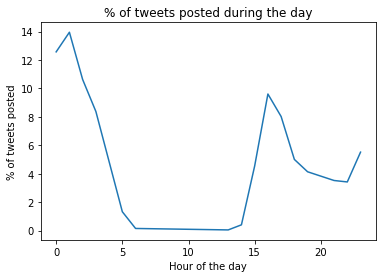

```python
t=(pd.DatetimeIndex(dog_rating.timestamp).hour.value_counts().sort_index())/len(dog_rating)*100
plt.plot(t.index,t)
plt.xlabel('Hour of the day')
plt.ylabel('% of tweets posted')
plt.title('% of tweets posted during the day');
```

**And they are most productive in December and least productive in August**

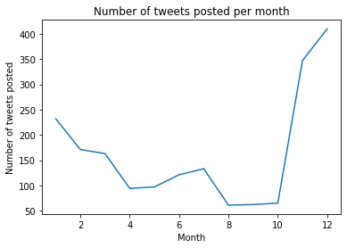

```python
m=pd.DatetimeIndex(dog_rating.timestamp).month.value_counts().sort_index()
plt.plot(m.index,m)
plt.xlabel('Month')
plt.ylabel('Number of tweets posted')
plt.title('Number of tweets posted per month');
```

**2.Almost all of them post tweets via Iphone twitter app**

```python
source=dog_rating.groupby(['source']).count()['tweet_id']/len(dog_rating)*100
source
```

```
source
TweetDeck             0.460123
Twitter Web Client    1.431493
Twitter for iPhone    98.108384
Name: tweet_id, dtype: float64
```

**3.The most popular dog names are Oliver,Cooper and Charlie.**

```python
dog_rating.query('name!="None"').name.value_counts()[:10]
```

```
Charlie    10
Oliver     10
Cooper     10
Lucy       9
Penny      9
Tucker     9
Sadie      8
Winston    8
Toby       7
Lola       7
Name: name, dtype: int64
```

**4. Not all photos are recognized as dogs by our image predictor. For those that are classified as dogs, the medium rating is 11.Still, some dogs received very low ratings.They are good dogs Brent!**

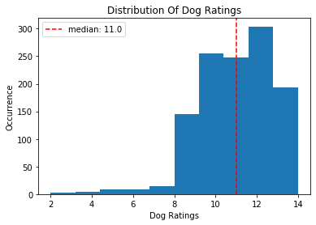

```python
dog_r=dog_rating.query('dog_or_not=="Yes"')
plt.hist(dog_r['rating'])
plt.axvline(dog_r['rating'].median(),color='r',linestyle='--',label='median: '+str(dog_r['rating'].median()))
plt.xlabel('Dog Ratings')
plt.ylabel('Occurrence')
plt.title('Distribution Of Dog Ratings')
plt.legend()
plt.show();
```

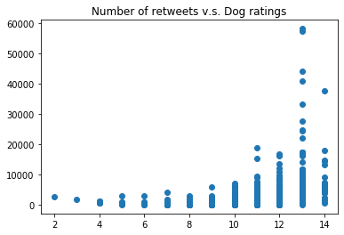

```
the max number of retweets: 78432.0
```

```python
plt.scatter('rating','retweet_count',data=dog_rating.query('dog_or_not=="Yes"'))
plt.title('Number of retweets v.s. Dog ratings')
plt.show()
print('the max number of retweets: '+str(dog_rating.retweet_count.max()));
```

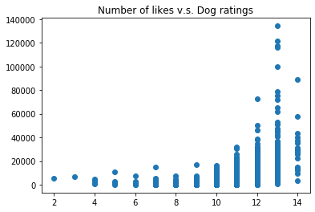

```
the max number of likes received: 157582.0
```

```python
plt.scatter('rating','favorite_count',data=dog_rating.query('dog_or_not=="Yes"'))
plt.title('Number of likes v.s. Dog ratings')
plt.show()
print('the max number of likes received: '+str(dog_rating.favorite_count.max()))
```

**6. What are the top 10 breeds based on the image predictor? Yes, we love golden retriever and labrador.**

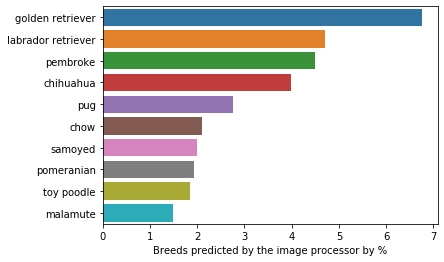

```python
top5_breed=dog_rating.pred_breed.value_counts()[:10]
top5_breed=top5_breed/len(dog_rating)*100
sns.barplot(x=top5_breed,y=top5_breed.index)
plt.xlabel('Breeds predicted by the image processor by %');
```

**7. I am crazy about floffers but they are unfortunately the least presented among our tweets. Floffer owners, sharing is caring please!**

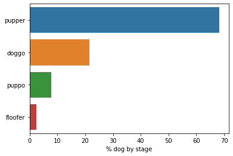

```python
df1=dog_rating.query('stage==["puppo","doggo","pupper","floofer"]')
stage=(df1.stage.value_counts()[:4])/len(df1)*100
stage.sort_values(ascending=False,inplace=True)
sns.barplot(x=stage,y=list(stage.index))
plt.xlabel('% dog by stage')
plt.show();
```

#### Does the result surprise you?

#### Let me tell you... I spent 90% of the time gathering, assessing and cleaning the data. It is a real pain. Unfortunately, the majority of the real-world data is messy and untidy. As a data analyst, data wrangling has become one of my main responsibilities.